# Normal Distribution

XDASI Fall 2021

10/14/2021

## Background

- **W&S Chapter 10: Normal Distribution**

### Additional Reading

- [**Aho - Chapter 3.1-3.2: Probability Density Functions (Part 1)**](https://xdas.bio.nyu.edu/references/Aho_Ch3.1-3.2_PDFs_Part1.pdf)
- [**Aho - Chapter 4.3: Statistics**](https://xdas.bio.nyu.edu/references/Aho_Ch_4.3_Statistics.pdf)
- [**Tranchina - Elements of Calculus**](https://xdas.bio.nyu.edu/references/CalculusReview_2.0.pdf)

## Normal distribution

The normal distribution is the most common distribution in statistics and has many applications in biology. It is important because it represents many processes in which the most likely outcome is the average. Large sums of (small) random variables are often normally distributed.

The Normal distribution is a **continuous** distribution with a characteristic bell shape, the precise dimensions of which are governed by its mean $\mu$ and standard deviation $\sigma$.

We say that “a random variable follows a normal distribution with mean mu and variance sigma” and notate this as $X \sim \mathcal{N}(\mu,\sigma^2)$, where $Exp(X) = \mu$ and $Var(X) = \sigma^2$.

The mathematical description of a normal distribution is:

PDF:
$$f(x) = \frac{1}{\sigma\sqrt{2\pi}} e^{-\frac{1}{2}
\left(\frac{x-\mu}{\sigma}\right)^2}$$

CDF:
$$F(x) = \int_{-\infty}^{\infty}
\frac{1}{\sigma\sqrt{2\pi}} e^{-\frac{1}{2}
\left(\frac{x-\mu}{\sigma}\right)^2}dx = 1$$

where:

1. Outcomes $x$ are continuous and independent.
2. $x \in \mathbb{R}$
3. $\mu \in \mathbb{R}$
4. $\sigma > 0$

Examples with different mean and SD are illustrated below.

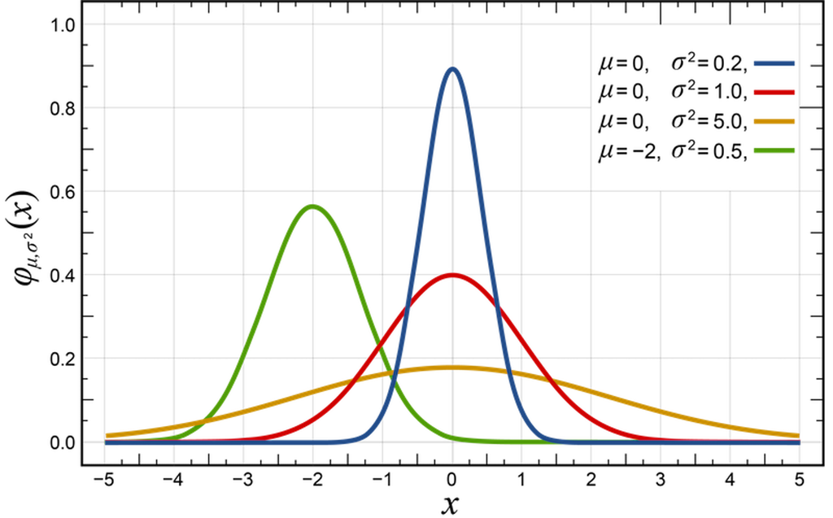

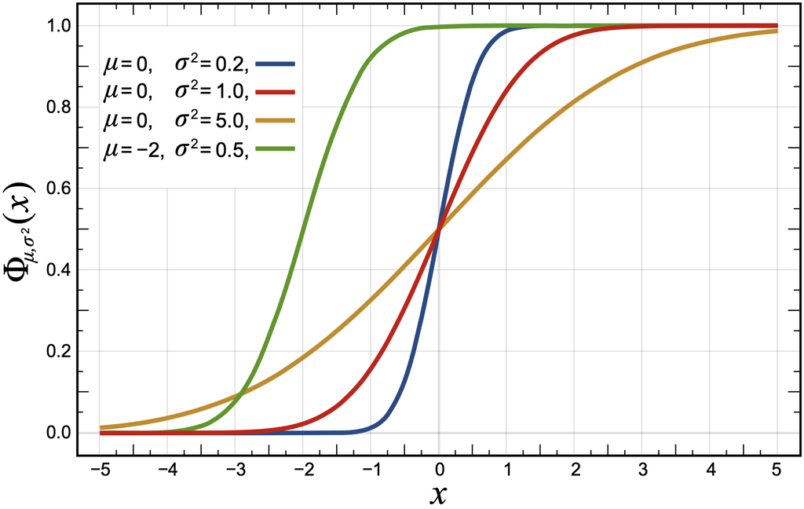

PDF and CDF for normal distributions with varying mean and SD

## Standard normal

The standard normal distribution, or *Z-distribution*, is a normal or Gaussian distribution with $\mu = 0$ and $\sigma = 1$: $Z$ ~ $N(0,1)$

The normal distribution is standardized by subtracting the mean and dividing over the SD:
$$Z = \frac{X - \mu}{\sigma}$$

Any outcome $x_i$ from a normal distribution can be turned into a $z$-score in the same maner.

As with any other distribution, we can ask questions like, “What is the chance of observing a value of $x$ or less? $x$ or more? between $x$ and $y$?”

We can also use the **inverse CDF**, or the *quantile* function, to find the value for some percentile in the population (e.g. the femur length that 80% of the population is under, which could be a factor in setting the seat pitch in airplanes).

#### Empirical rule for the standard normal

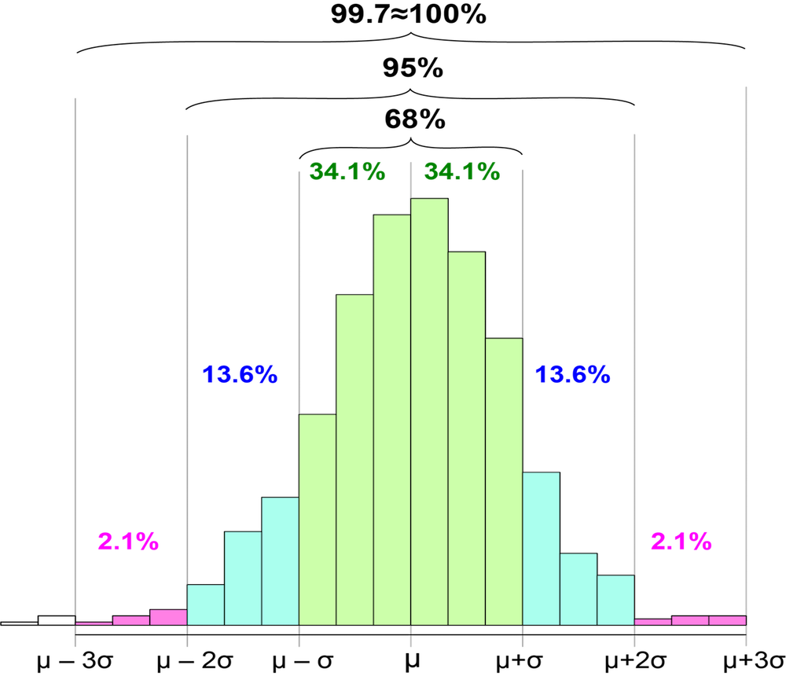

Empirical rule for the normal distribution

#### What controls the shape of the distribution?

*Bell-shaped curve*: This is governed by the general formula $y = e^{-x^2}$. The height of this curve at $x = 0$ (i.e. the y-intercept) is $y = 1$.

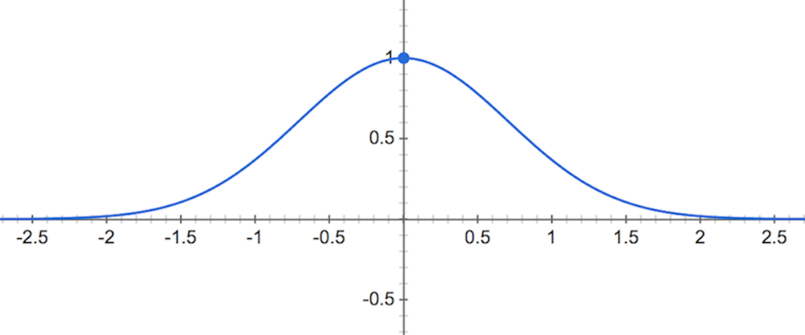

Exponential bell curve

The total area under the curve $e^{-x^2}$ is:

$$\int_{-\infty}^{\infty}e^{-x^2}dx = \sqrt{\pi} \approx 1.77$$

*Width and location of the curve*: This is governed by the value of the exponent. The Normal distribution is expressed in terms of the mean, $\mu$, and the variance, $\sigma^2$, of the data. Substituting the exponent with the term ${-\frac{1}{2}\left(\frac{x-\mu}{\sigma}\right)^2}$ gives a curve that is zero-centered around the mean $\mu$ and has a standard deviation of $\sigma$.

*Area under the curve*: In order to make the total probability equal to one, we use a scaling factor (let’s call this a constant $C$) that is a multiplier of the exponential formula. This constant turns out to be $C = \frac{1}{\sigma\sqrt{2\pi}}$.

Deriving these equations is not trivial. We end up with the magical number $\pi$ in the equation because it turns out that using a polar coordinate system, instead of Cartesian coordinates, is more natural to describe this shape. If you want to get an idea of how the Normal PDF is derived, check out this video on YouTube: [**Quick derivation of the Normal PDF (4’50”)**](https://www.youtube.com/watch?v=ebewBjZmZTw) (https://www.youtube.com/watch?v=ebewBjZmZTw).

## Normal approximation of the binomial

When the sample size is large, and $p \approx 0.5$ (not too large or too small), the normal distribution is a very good approximation to the binomial.

## Example

The average weight of an adult female greyhound is 63 pounds, with a standard deviation of 8 pounds. What proportion of female greyhounds weigh less than or equal to 55 pounds?

```r
pnorm(55, mean = 63, sd = 8)
```

```
## [1] 0.1586553
```

What proportion weigh between 60 and 65 pounds?

$$P(60 \le X \le 65) = \int_{60}^{65}f(x)dx =\Big[ F(x) \Big]_{60}^{65} \\
= \int_{-\infty}^{65}f(x)dx -
\int_{-\infty}^{60}f(x)dx = F(65) - F(60)$$

```r
# note that you cannot use the summation method for a continuous distribution;
# you have to subtract CDF up to each point to get the probability for the interval
pnorm(65, mean = 63, sd = 8) - pnorm(60, mean = 63, sd = 8)
```

```
## [1] 0.2448761
```

It can safely be said that 75% weigh no more than what amount? This is a question that calls for the quantile function (inverse CDF):

```r
qnorm(0.75, mean = 63, sd = 8)
```

```
## [1] 68.39592
```